# Analysing Income Inequalities using R

Project by: Akshay Shyam Bhagwat

```r
#loading the libraries
library(tidyverse)
```

```r
library(ggplot2)
library(reshape2)
```

# 1. INTRODUCTION

```r
# Load the dataset
data <- read.csv("nlsy97.csv")

summary(data)
```

```
##     B0004600         E8043100          E8043200         E8043400
##  Min.   : -5.00   Min.   :-3.0000   Min.   :-4.000   Min.   : -4.000
##  1st Qu.: -5.00   1st Qu.: 0.0000   1st Qu.:-4.000   1st Qu.: -4.000
##  Median : -4.00   Median : 0.0000   Median :-4.000   Median : -4.000
##  Mean   : 92.01   Mean   : 0.1802   Mean   :-1.248   Mean   : -1.466
##  3rd Qu.:231.00   3rd Qu.: 0.0000   3rd Qu.:-4.000   3rd Qu.: -4.000
##  Max.   :400.00   Max.   :11.0000   Max.   :37.000   Max.   :207.000
##     R0000100       R0069400         R0070000         R0323900
##  Min.   :   1   Min.   :-4.000   Min.   :-4.000   Min.   :-4.0000
##  1st Qu.:2249   1st Qu.: 2.000   1st Qu.: 1.000   1st Qu.:-4.0000
##  Median :4502   Median : 2.000   Median : 2.000   Median : 0.0000
##  Mean   :4504   Mean   : 1.973   Mean   : 1.849   Mean   :-0.6243
##  3rd Qu.:6758   3rd Qu.: 2.000   3rd Qu.: 2.000   3rd Qu.: 1.0000
##  Max.   :9022   Max.   : 4.000   Max.   : 4.000   Max.   : 7.0000
##     R0358900          R0513500         R0514700         R0514800
##  Min.   :-3.0000   Min.   : -4.00   Min.   : -4.00   Min.   : -4.0000
##  1st Qu.: 0.0000   1st Qu.: -4.00   1st Qu.: -4.00   1st Qu.: -4.0000
##  Median : 0.0000   Median : -4.00   Median : -4.00   Median : -4.0000
##  Mean   : 0.1942   Mean   : 16.93   Mean   : 34.21   Mean   : -0.3467
##  3rd Qu.: 0.0000   3rd Qu.: 30.00   3rd Qu.:100.00   3rd Qu.:  0.0000
##  Max.   : 1.0000   Max.   :100.00   Max.   :100.00   Max.   :100.0000
##     R0514900          R0515100         R0536300        R0536401
##  Min.   : -4.000   Min.   : -4.00   Min.   :1.000   Min.   : 1.000
##  1st Qu.: -4.000   1st Qu.: -4.00   1st Qu.:1.000   1st Qu.: 3.000
##  Median : -4.000   Median : -4.00   Median :1.000   Median : 7.000
##  Mean   :  4.464   Mean   : 26.02   Mean   :1.488   Mean   : 6.556
##  3rd Qu.:  0.000   3rd Qu.: 75.00   3rd Qu.:2.000   3rd Qu.:10.000
##  Max.   :100.000   Max.   :100.00   Max.   :2.000   Max.   :12.000
##     R0536402       R0648900         R0649100          R0681300
##  Min.   :1980   Min.   :-4.000   Min.   :-4.0000   Min.   :-4.0000
##  1st Qu.:1981   1st Qu.: 0.000   1st Qu.: 0.0000   1st Qu.: 0.0000
##  Median :1982   Median : 0.000   Median : 0.0000   Median : 0.0000
##  Mean   :1982   Mean   :-0.439   Mean   :-0.2488   Mean   :-0.4243
##  3rd Qu.:1983   3rd Qu.: 0.000   3rd Qu.: 1.0000   3rd Qu.: 0.0000
##  Max.   :1984   Max.   : 1.000   Max.   : 1.0000   Max.   : 1.0000
##     R0690800         R0691200         R1194000        R1200100
##  Min.   :-4.000   Min.   :-4.000   Min.   :12.00   Min.   :-3.00
##  1st Qu.:-4.000   1st Qu.:-4.000   1st Qu.:13.00   1st Qu.:18.00
##  Median :-4.000   Median :-4.000   Median :14.00   Median :22.00
##  Mean   :-3.232   Mean   :-3.174   Mean   :13.99   Mean   :20.69
```

[output cut: 113 more lines]

```
##  Max.   : 6.000   Max.   : 6.00   Max.   : 600000   Max.   : 600000
##     Z9049800         Z9050100         Z9121900           Z9122000
##  Min.   :    -4   Min.   :    -4   Min.   :-5014150   Min.   :    -4
##  1st Qu.:     0   1st Qu.:     0   1st Qu.:      -4   1st Qu.:     0
##  Median :    50   Median :     0   Median :    3996   Median :     0
##  Mean   :  8270   Mean   :  3164   Mean   :   37927   Mean   : 45006
##  3rd Qu.:  3000   3rd Qu.:  2800   3rd Qu.:   37947   3rd Qu.:  8000
##  Max.   :300000   Max.   :200000   Max.   :  600000   Max.   :425000
##     Z9122200         Z9122300         Z9122500
##  Min.   :-4.000   Min.   :    -4   Min.   :    -4
##  1st Qu.: 1.000   1st Qu.:     0   1st Qu.:     0
##  Median : 6.000   Median :   500   Median :  1500
##  Mean   : 3.517   Mean   : 17427   Mean   : 13775
##  3rd Qu.: 6.000   3rd Qu.: 11000   3rd Qu.: 18000
##  Max.   : 9.000   Max.   :300000   Max.   :370000
```

```r
# Replace negative values (except -1) with NA
data <- data %>%
  mutate(across(everything(), ~ ifelse(. < -1, NA, .)))

colSums(is.na(data))
```

```
## B0004600 E8043100 E8043200 E8043400 R0000100 R0069400 R0070000 R0323900
##     5544       21     8064     8080        0       17       23     3613
## R0358900 R0513500 R0514700 R0514800 R0514900 R0515100 R0536300 R0536401
##        7     5480     5458     5463     5491     5471        0        0
## R0536402 R0648900 R0649100 R0681300 R0690800 R0691200 R1194000 R1200100
##        0     1102     1160     1098     7398     7274        0      717
## R1200200 R1201300 R1201400 R1204700 R1205300 R1210500 R1217600 R1235800
##      608     1042        2     2791       31     2148     2198        0
## R1302400 R1302500 R1302600 R1302700 R1482600 R1700500 R1701100 R2191500
##     1856      688     3277      974        0     5574     7791      604
## R4908500 S0920000 S0920700 S2011600 S3805200 S4677200 S4685800 S6320000
##     6973     4097     4096     7180     7486     1600     1544     8979
## T0026000 T1069100 T1069101 T1069102 T1069103 T3611600 T6650100 T6656700
##     5872     7143     7152     7147     7157     5226     7550     2456
## T6656900 T6657000 T6657100 T6657300 T6663100 T6767000 T7635600 T7635700
##     1561     1588     1588     1621     4771     7433     1674     1672
## T7635800 T7638800 T7639200 T7639800 T7640000 T7640300 T7640400 T7731100
##     1691     1584     1675     7824     1672     1699     1692     2818
## U0014800 U1718000 U1719400 U1852400 U2857000 U2857200 U2857300 U2858100
##     4211     3170     3132     2312     2262     3825     8567     4826
## U2858500 U2858600 Z9031500 Z9033700 Z9033900 Z9034100 Z9048900 Z9049000
##     5847     8617     7080     6518     6556     6979     1830     3576
## Z9049800 Z9050100 Z9121900 Z9122000 Z9122200 Z9122300 Z9122500
##     1945      609     3462     1342     1291     1968     1527
```

```r
#Renaming the variables to understand them better.
data <- data %>%
  rename(
    incarcerations = E8043100,
    teachers_quality = R0069400,
    marijuana_use = R0358900,
    gender = R0536300,
    age_1996 = R1194000,
    parent_relationship = R1205300,
    mom_education = R1302500,
    dad_education = R1302400,
    cocaine_use = R2191500,
    income = U2857200
)
head(data)
```

```
##   B0004600 incarcerations E8043200 E8043400 R0000100 teachers_quality R0070000
## 1       NA              0       NA       NA        1                1        1
## 2       NA              0       NA       NA        2                2        2
## 3       NA              0       NA       NA        3                2        3
## 4       NA              0       NA       NA        4                2        3
## 5       NA              0       NA       NA        5                2        2
## 6       41              0       NA       NA        6                2        2
##   R0323900 marijuana_use R0513500 R0514700 R0514800 R0514900 R0515100 gender
## 1       NA             0       10      100       10        0      100      2
## 2        3             0       NA       NA       NA       NA       NA      1
## 3        0             0       NA       NA       NA       NA       NA      2
## 4       NA             0       46      100        0        0      100      2
## 5        3             1       NA       NA       NA       NA       NA      1
## 6        4             0       NA       NA       NA       NA       NA      2
##   R0536401 R0536402 R0648900 R0649100 R0681300 R0690800 R0691200 age_1996
```

[output cut: 76 more lines]

```r
summary(data)
```

```
##     B0004600     incarcerations       E8043200        E8043400
##  Min.   :  0.0   Min.   : 0.0000   Min.   :12.00   Min.   :  1.00
##  1st Qu.:197.0   1st Qu.: 0.0000   1st Qu.:19.00   1st Qu.:  2.00
##  Median :273.0   Median : 0.0000   Median :22.00   Median :  9.00
##  Mean   :247.9   Mean   : 0.1877   Mean   :22.86   Mean   : 21.16
##  3rd Qu.:327.0   3rd Qu.: 0.0000   3rd Qu.:26.00   3rd Qu.: 26.00
##  Max.   :400.0   Max.   :11.0000   Max.   :37.00   Max.   :207.00
##  NA's   :5544    NA's   :21        NA's   :8064    NA's   :8080
##     R0000100    teachers_quality    R0070000         R0323900
##  Min.   :   1   Min.   :-1.000   Min.   :-1.000   Min.   :-1.000
##  1st Qu.:2249   1st Qu.: 2.000   1st Qu.: 1.000   1st Qu.: 0.000
##  Median :4502   Median : 2.000   Median : 2.000   Median : 1.000
##  Mean   :4504   Mean   : 1.984   Mean   : 1.862   Mean   : 1.643
##  3rd Qu.:6758   3rd Qu.: 2.000   3rd Qu.: 2.000   3rd Qu.: 2.000
##  Max.   :9022   Max.   : 4.000   Max.   : 4.000   Max.   : 7.000
##                 NA's   :17       NA's   :23       NA's   :3613
##  marijuana_use        R0513500         R0514700         R0514800
##  Min.   :-1.0000   Min.   : -1.00   Min.   : -1.00   Min.   : -1.000
##  1st Qu.: 0.0000   1st Qu.: 20.00   1st Qu.:100.00   1st Qu.:  0.000
##  Median : 0.0000   Median : 50.00   Median :100.00   Median :  0.000
##  Mean   : 0.1962   Mean   : 49.64   Mean   : 93.33   Mean   :  5.305
##  3rd Qu.: 0.0000   3rd Qu.: 80.00   3rd Qu.:100.00   3rd Qu.:  4.000
##  Max.   : 1.0000   Max.   :100.00   Max.   :100.00   Max.   :100.000
##  NA's   :7         NA's   :5480     NA's   :5458     NA's   :5463
##     R0514900         R0515100          gender         R0536401
##  Min.   : -1.00   Min.   : -1.00   Min.   :1.000   Min.   : 1.000
##  1st Qu.:  0.00   1st Qu.: 50.00   1st Qu.:1.000   1st Qu.: 3.000
##  Median :  4.00   Median : 85.00   Median :1.000   Median : 7.000
##  Mean   : 17.73   Mean   : 72.74   Mean   :1.488   Mean   : 6.556
##  3rd Qu.: 25.00   3rd Qu.:100.00   3rd Qu.:2.000   3rd Qu.:10.000
##  Max.   :100.00   Max.   :100.00   Max.   :2.000   Max.   :12.000
##  NA's   :5491     NA's   :5471
##     R0536402       R0648900          R0649100         R0681300
##  Min.   :1980   Min.   :-1.0000   Min.   :-1.000   Min.   :-1.000
##  1st Qu.:1981   1st Qu.: 0.0000   1st Qu.: 0.000   1st Qu.: 0.000
##  Median :1982   Median : 0.0000   Median : 0.000   Median : 0.000
##  Mean   :1982   Mean   : 0.0543   Mean   : 0.288   Mean   : 0.072
##  3rd Qu.:1983   3rd Qu.: 0.0000   3rd Qu.: 1.000   3rd Qu.: 0.000
##  Max.   :1984   Max.   : 1.0000   Max.   : 1.000   Max.   : 1.000
##                 NA's   :1102      NA's   :1160     NA's   :1098
```

[output cut: 137 more lines]

```
##  Min.   :     0   Min.   :     0   Min.   :     0   Min.   :1.000
##  1st Qu.:     0   1st Qu.:  7008   1st Qu.:     0   1st Qu.:1.000
##  Median :     0   Median : 23000   Median :     0   Median :6.000
##  Mean   :  3395   Mean   : 69543   Mean   : 52911   Mean   :4.776
##  3rd Qu.:  3300   3rd Qu.: 80350   3rd Qu.: 75000   3rd Qu.:6.000
##  Max.   :200000   Max.   :600000   Max.   :425000   Max.   :9.000
##  NA's   :609      NA's   :3462     NA's   :1342     NA's   :1291
##     Z9122300         Z9122500
##  Min.   :     0   Min.   :     0
##  1st Qu.:     0   1st Qu.:     0
##  Median :  2500   Median :  5000
##  Mean   : 22316   Mean   : 16597
##  3rd Qu.: 20000   3rd Qu.: 22000
##  Max.   :300000   Max.   :370000
##  NA's   :1968     NA's   :1527
```

```r
# Keep only selected variables
data <- data %>%
  select(income, gender, incarcerations, mom_education, dad_education,
         age_1996, cocaine_use, teachers_quality, parent_relationship, marijuana_use)

# Verify structure
str(data)
```

```
## 'data.frame':    8984 obs. of  10 variables:
##  $ income             : int  NA 116000 -1 45000 125000 NA NA NA 59000 75000 ...
##  $ gender             : int  2 1 2 2 1 2 1 2 1 1 ...
##  $ incarcerations     : int  0 0 0 0 0 0 0 0 0 0 ...
##  $ mom_education      : int  8 15 12 12 12 12 12 12 12 12 ...
##  $ dad_education      : int  16 17 NA 12 12 NA NA 6 6 6 ...
##  $ age_1996           : int  15 14 13 15 14 14 13 15 14 12 ...
##  $ cocaine_use        : int  0 0 0 0 0 0 0 1 0 0 ...
##  $ teachers_quality   : int  1 2 2 2 2 2 2 1 1 1 ...
##  $ parent_relationship: int  1 2 4 4 1 4 4 1 1 1 ...
##  $ marijuana_use      : int  0 0 0 0 1 0 0 0 0 0 ...
```

```r
summary(data)
```

```
##      income           gender      incarcerations    mom_education
##  Min.   :    -1   Min.   :1.000   Min.   : 0.0000   Min.   : 1.0
##  1st Qu.: 25000   1st Qu.:1.000   1st Qu.: 0.0000   1st Qu.:12.0
##  Median : 40000   Median :1.000   Median : 0.0000   Median :12.0
##  Mean   : 48825   Mean   :1.488   Mean   : 0.1877   Mean   :12.5
##  3rd Qu.: 61000   3rd Qu.:2.000   3rd Qu.: 0.0000   3rd Qu.:14.0
##  Max.   :235884   Max.   :2.000   Max.   :11.0000   Max.   :95.0
##  NA's   :3825                     NA's   :21        NA's   :688
##  dad_education      age_1996      cocaine_use      teachers_quality
##  Min.   : 1.00   Min.   :12.00   Min.   :-1.0000   Min.   :-1.000
##  1st Qu.:12.00   1st Qu.:13.00   1st Qu.: 0.0000   1st Qu.: 2.000
##  Median :12.00   Median :14.00   Median : 0.0000   Median : 2.000
##  Mean   :12.66   Mean   :13.99   Mean   : 0.0588   Mean   : 1.984
##  3rd Qu.:14.00   3rd Qu.:15.00   3rd Qu.: 0.0000   3rd Qu.: 2.000
##  Max.   :95.00   Max.   :16.00   Max.   : 1.0000   Max.   : 4.000
##  NA's   :1856                    NA's   :604       NA's   :17
##  parent_relationship marijuana_use
##  Min.   : 1.000      Min.   :-1.0000
##  1st Qu.: 1.000      1st Qu.: 0.0000
##  Median : 2.000      Median : 0.0000
##  Mean   : 2.551      Mean   : 0.1962
##  3rd Qu.: 4.000      3rd Qu.: 0.0000
##  Max.   :10.000      Max.   : 1.0000
##  NA's   :31          NA's   :7
```

```r
#Replacing NA values
data <- data %>%
  mutate(
    # Critical variables: Replace with median or "Unknown"
    income = ifelse(is.na(income), mean(income, na.rm = TRUE), income),
    dad_education = ifelse(is.na(dad_education), median(dad_education, na.rm = TRUE), dad_education),
    mom_education = ifelse(is.na(mom_education), median(mom_education, na.rm = TRUE), mom_education),

    # Behavioral variables: Replace with "Unknown"
    cocaine_use = ifelse(is.na(cocaine_use), "Unknown", cocaine_use),
    marijuana_use = ifelse(is.na(marijuana_use), "Unknown", marijuana_use),
    teachers_quality = ifelse(is.na(teachers_quality), "Unknown", teachers_quality),

    # Parental relationship: Replace with "Unknown"
    parent_relationship = ifelse(is.na(parent_relationship), "Unknown", parent_relationship),

    # incarcerations
    incarcerations = ifelse(is.na(incarcerations), "Unknown" , incarcerations)
  )
```

```r
#Recoding factor variables.

#Gender:
data <- data %>%
  mutate(gender = factor(gender, levels = c(1, 2), labels = c("Male", "Female")))



# Teacher's quailty:
data <- data %>%
  mutate(teachers_quality = case_when(
    teachers_quality == -1 ~ "Refusal",
    teachers_quality == 1 ~ "Strongly Agree",
    teachers_quality == 2 ~ "Agree",
    teachers_quality == 3 ~ "Disagree",
    teachers_quality == 4 ~ "Strongly Disagree",
    TRUE ~ "Unknown"
  )) %>%
  mutate(teachers_quality = factor(teachers_quality,
                                   levels = c("Refusal", "Strongly Agree", "Agree", "Disagree", "Strongly Disagree", "Unknown")))

#Parent's Relationship:

data <- data %>%
  mutate(parent_relationship = case_when(
    parent_relationship == 1 ~ "Both Biological Parents",
    parent_relationship %in% c(2, 3) ~ "One Biological parent)",
    parent_relationship %in% c(4, 5) ~ "Single Biological Parent",
    parent_relationship %in% c(6, 7) ~ "Adoptive Parents",
    parent_relationship %in% c(8, 9, 10) ~ "No Parents",
    TRUE ~ "Unknown"
  )) %>%
  mutate(parent_relationship = factor(parent_relationship,
                                      levels = c("Both Biological Parents",
                                                 "One Biological parent)",
                                                 "Single Biological Parent",
                                                 "Adoptive Parents",
                                                 "No Parents",
                                                 "Unknown")))

# incarcerations
data$incarcerations <- as.numeric(data$incarcerations)
# mom education
data <- data %>%
  mutate(mom_education = case_when(
    mom_education %in% c(1:8) ~ "Grade School",
    mom_education %in% c(9:12) ~ "High School",
    mom_education %in% c(13:20) ~ "College",
    mom_education %in% c(95) ~ "Ungraded",
    TRUE ~ "Unknown"
  )) %>%
  mutate(mom_education = factor(mom_education,
                                levels = c("Grade School",
                                     "High School",
                                     "College",
                                     "Ungraded")))

# dad education
data <- data %>%
  mutate(dad_education = case_when(
    dad_education %in% c(1:8) ~ "Grade School",
    dad_education %in% c(9:12) ~ "High School",
    dad_education %in% c(13:20) ~ "College",
    dad_education %in% c(95) ~ "Ungraded",
    TRUE ~ "Unknown"
  )) %>%
  mutate(dad_education = factor(dad_education,
                                levels = c("Grade School",
                                     "High School",
                                     "College",
                                     "Ungraded")))

#Marijuana & Cocaine Use:

data <- data %>%
  mutate(
    marijuana_use = case_when(
      marijuana_use == -1 ~ "Refusal",
      marijuana_use == 0 ~ "No",
      marijuana_use == 1 ~ "Yes",
      TRUE ~ "Unknown"
    ),
    cocaine_use = case_when(
      cocaine_use == -1 ~ "Refusal",
      cocaine_use == 0 ~ "No",
      cocaine_use == 1 ~ "Yes",
      TRUE ~ "Unknown"
    )
  ) %>%
  mutate(
    marijuana_use = factor(marijuana_use, levels = c("Refusal", "No", "Yes", "Unknown")),
    cocaine_use = factor(cocaine_use, levels = c("Refusal", "No", "Yes", "Unknown"))
  )

table(data$gender, useNA = "ifany")
```

```
##
##   Male Female
##   4599   4385
```

```r
table(data$teachers_quality, useNA = "ifany")
```

```
##
##           Refusal    Strongly Agree             Agree          Disagree
##                 2              1573              6192               964
## Strongly Disagree           Unknown
##               236                17
```

```r
table(data$marijuana_use, useNA = "ifany")
```

```
##
## Refusal      No     Yes Unknown
##      34    7148    1795       7
```

```r
table(data$cocaine_use, useNA = "ifany")
```

```
##
## Refusal      No     Yes Unknown
##      28    7831     521     604
```

```r
summary(data)
```

```
##      income          gender     incarcerations         mom_education
##  Min.   :    -1   Male  :4599   Min.   : 0.0000   Grade School: 694
##  1st Qu.: 36000   Female:4385   1st Qu.: 0.0000   High School :4989
##  Median : 48825                 Median : 0.0000   College     :3295
##  Mean   : 48825                 Mean   : 0.1877   Ungraded    :   6
##  3rd Qu.: 48825                 3rd Qu.: 0.0000
##  Max.   :235884                 Max.   :11.0000
##                                 NA's   :21
##       dad_education     age_1996      cocaine_use            teachers_quality
##  Grade School: 664   Min.   :12.00   Refusal:  28   Refusal          :   2
##  High School :5549   1st Qu.:13.00   No     :7831   Strongly Agree   :1573
##  College     :2763   Median :14.00   Yes    : 521   Agree            :6192
##  Ungraded    :   8   Mean   :13.99   Unknown: 604   Disagree         : 964
##                      3rd Qu.:15.00                  Strongly Disagree: 236
##                      Max.   :16.00                  Unknown          :  17
##
##                parent_relationship marijuana_use
##  Both Biological Parents :4395     Refusal:  34
##  One Biological parent)  :1205     No     :7148
##  Single Biological Parent:2826     Yes    :1795
##  Adoptive Parents        : 147     Unknown:   7
##  No Parents              : 380
##  Unknown                 :  31
##
```

From this quick table summary of our categorized data, you can see that there is a large population of data that can be utilized in our report. We factorized key categorical variables to assign meaningful labels and ensure they are ready for analysis. This process involved recoding raw numeric values (e.g., 1 for Male, 2 for Female) into descriptive labels, such as “Male” and “Female”, for better readability and understanding The data points that we chose to work with are outlined below, along with factor level names to better understand the data. * gender (the gender of the respondents) - Male - Female * income (the total income in USD from salaries and wages) * incarcerations (total number of incarcerations) * mom_education (biological mothers highest grade completed) - Grade school - High school - College - Ungraded * dad_education (biological fathers highest grade completed) - Grade school - High school - College - Ungraded * age_1996 (age as of 12/31/96) * marijuana_use (has the respondent ever used Marijuana) - Yes - No - Refusal - Unknown * cocaine_use (has the respondent ever used cocaine or hard drugs) - Yes - No - Refusal - Unknown * parent_relationship (respondent’s relationship to household parent figure) - Both Biological Parents - One Biological parent - Single Biological Parent - Adoptive Parents - No Parents - Unknown * teachers_quality (are the teachers good?) - Strongly Agree - Agree - Disagree - Strongly Disagree - Refusal - Unknown

From the basic tables above the count of the data that has factor level naming has been given, otherwise for data points like income and age a five number summary is given.

###Code for Summaries:

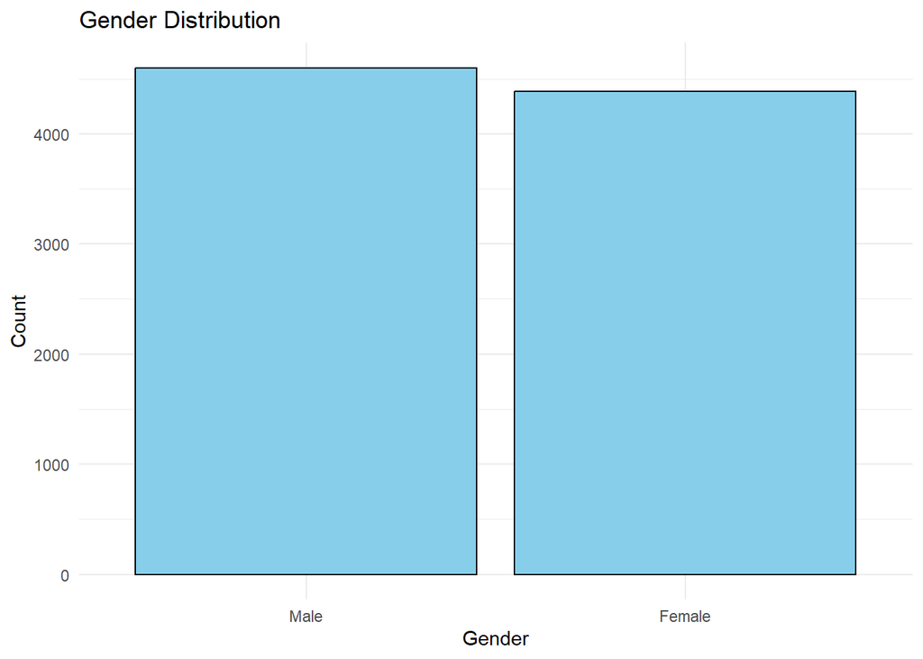

```r
# Gender Distribution
ggplot(data, aes(x = gender)) +
  geom_bar(fill = "skyblue", color = "black") +
  theme_minimal() +
  labs(
    title = "Gender Distribution",
    x = "Gender",
    y = "Count"
  )
```

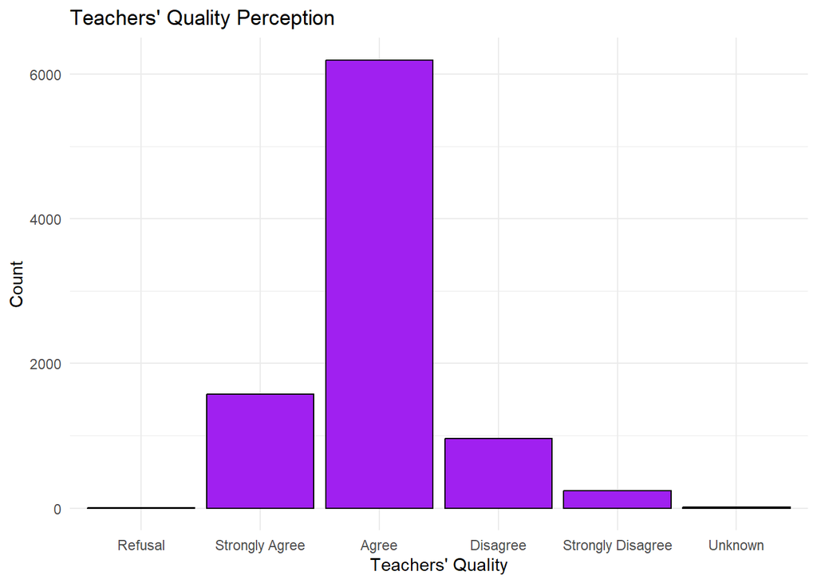

```r
# Teachers' Quality Distribution
ggplot(data, aes(x = teachers_quality)) +
  geom_bar(fill = "purple", color = "black") +
  theme_minimal() +
  labs(
    title = "Teachers' Quality Perception",
    x = "Teachers' Quality",
    y = "Count"
  )
```

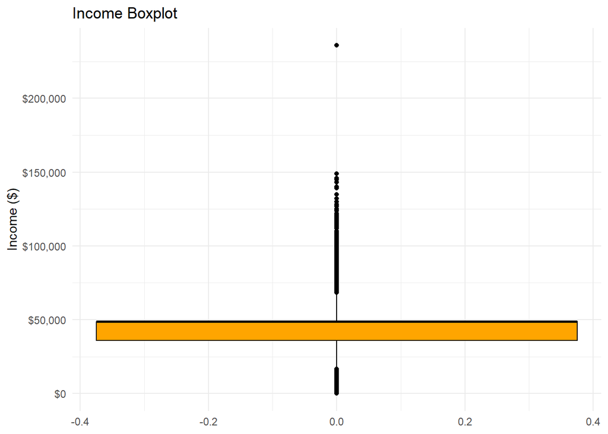

```r
# Boxplot for Income
ggplot(data, aes(y = income)) +
  geom_boxplot(fill = "orange", color = "black") +
  theme_minimal() +
  labs(
    title = "Income Boxplot",
    y = "Income ($)"
  ) +
  scale_y_continuous(labels = scales::dollar_format())
```

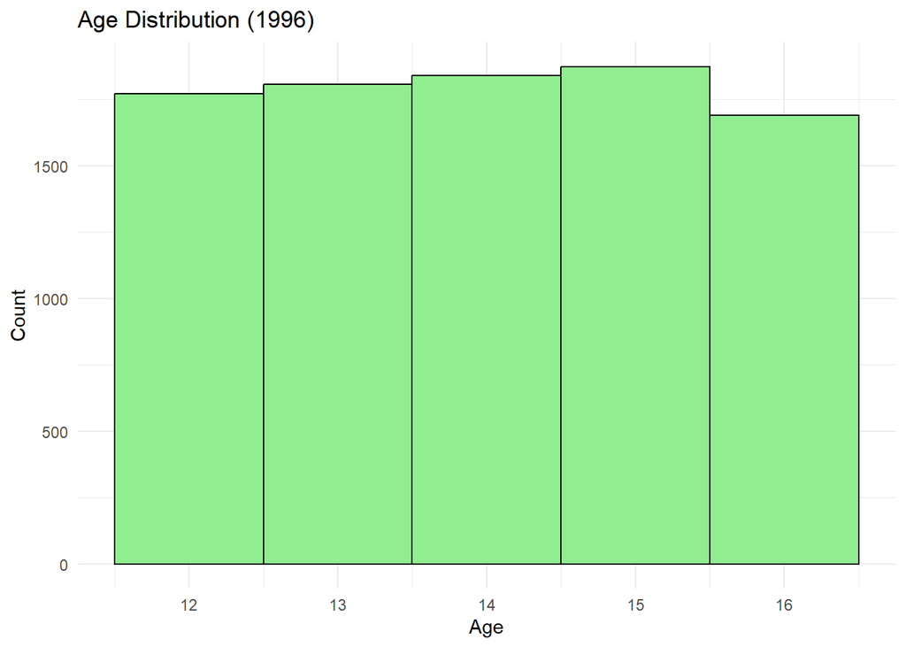

```r
# Histogram for Age
ggplot(data, aes(x = age_1996)) +
  geom_histogram(binwidth = 1, fill = "lightgreen", color = "black") +
  theme_minimal() +
  labs(
    title = "Age Distribution (1996)",
    x = "Age",
    y = "Count"
  )
```

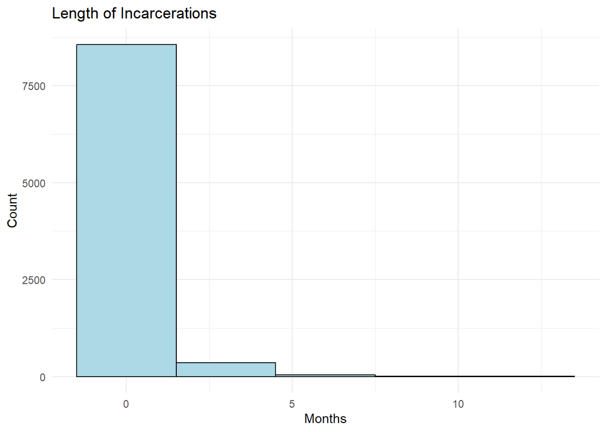

```r
# incarceration

ggplot(data, aes(x = incarcerations)) +
  geom_histogram(binwidth = 3, fill = "lightblue", color = "black") +
  theme_minimal() +
  labs(
    title = "Length of Incarcerations",
    x = "Months",
    y = "Count"
  )
```

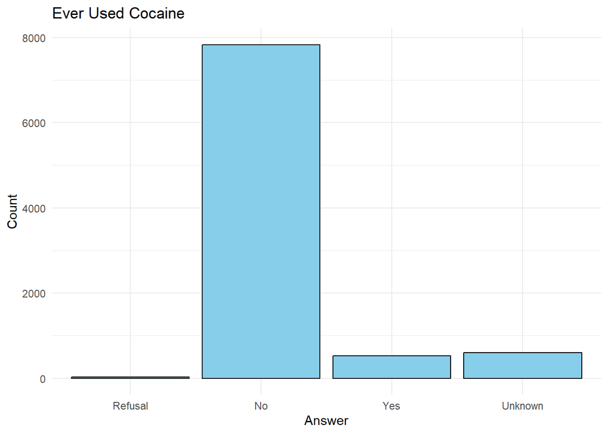

```r
# cocaine use

ggplot(data, aes(x = cocaine_use)) +
  geom_bar(fill = "skyblue", color = "black") +
  theme_minimal() +
  labs(
    title = "Ever Used Cocaine",
    x = "Answer",
    y = "Count"
  )
```

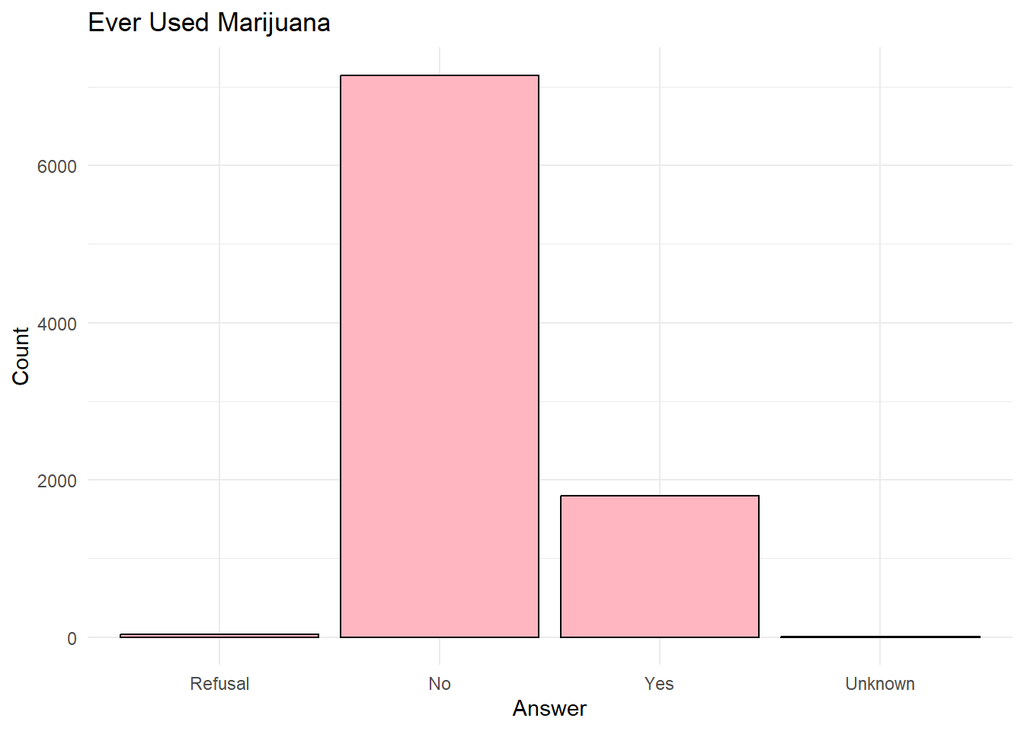

```r
# marijuana use

ggplot(data, aes(x = marijuana_use)) +
  geom_bar(fill = "lightpink", color = "black") +
  theme_minimal() +
  labs(
    title = "Ever Used Marijuana",
    x = "Answer",
    y = "Count"
  )
```

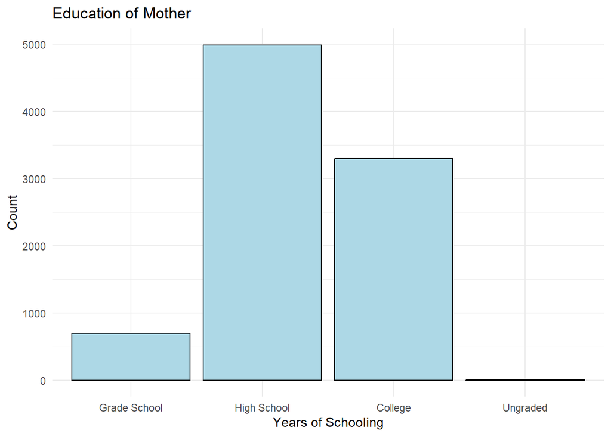

```r
# mom education
ggplot(data, aes(x = mom_education)) +
  geom_bar(fill = "lightblue", color = "black") +
  theme_minimal() +
  labs(
    title = "Education of Mother",
    x = "Years of Schooling",
    y = "Count"
  )
```

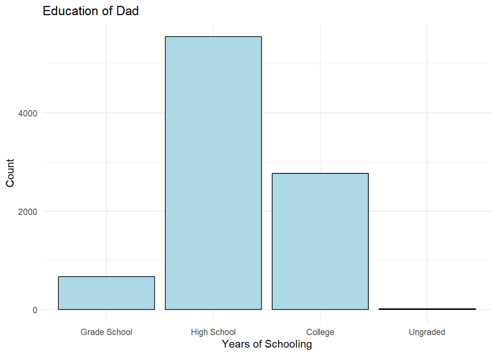

```r
# dad education
ggplot(data, aes(x = dad_education)) +
  geom_bar(fill = "lightblue", color = "black") +
  theme_minimal() +
  labs(
    title = "Education of Dad",
    x = "Years of Schooling",
    y = "Count"
  )
```

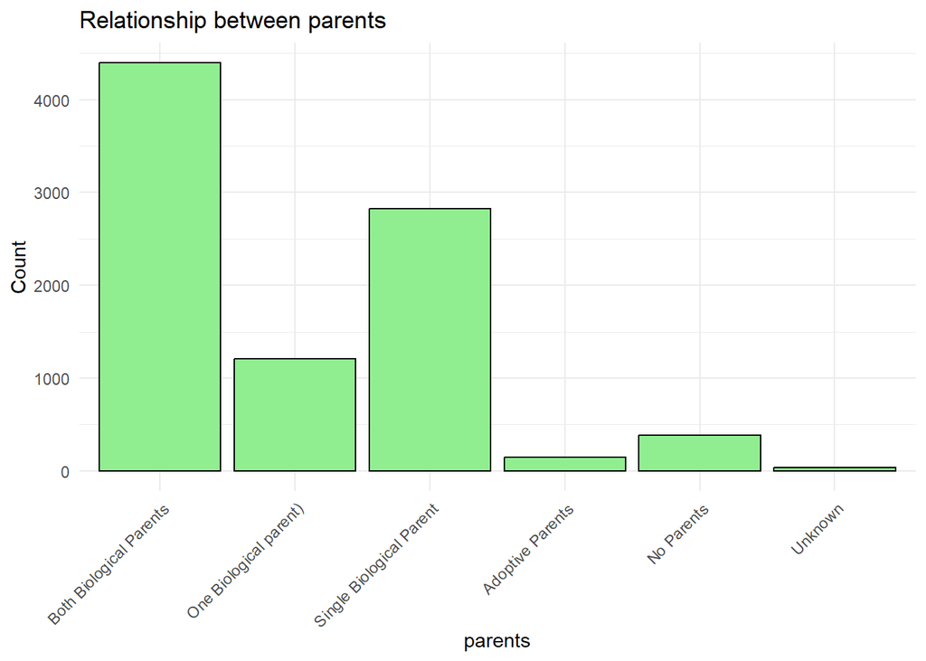

```r
# parents relationship

ggplot(data, aes(x = parent_relationship)) +
  geom_bar(fill = "lightgreen", color = "black") +
  theme_minimal() +
  labs(
    title = "Relationship between parents",
    x = "parents",
    y = "Count"
  ) +
  theme(axis.text.x = element_text(angle = 45, hjust = 1))
```

### Section:2 Methodology

2. How did you deal with topcoded variables?
- The income variable is topcoded at $200,000. This means we don’t know the exact incomes for the top 2% of earners because their income is replaced by an average value.
- We kept the topcoded value as it is, so we didn’t lose high-income earners from the analysis.
- However, we noted that this makes it hard to analyze how much these top earners actually earn. For example, we can’t know if there are big income gaps among the richest people, which could affect our understanding of income inequality.
3. Did you produce any tables or plots that you thought would reveal interesting trends but didn’t?

*Drug Use (Marijuana and Cocaine) vs Income:* we created boxplots to compare income between individuals who reported drug use (marijuana or cocaine) and those who didn’t. I hypothesized that drug use might correlate with lower income due to its potential socioeconomic impacts. The results were inconclusive. Both users and non-users had high-income outliers, and the overall income distribution didn’t differ significantly between the groups.

*Teacher’s Quality vs Income:* we analyzed the relationship between perceived teacher quality and income, expecting that positive perceptions of teacher quality might be associated with better educational outcomes and higher income. The analysis showed no clear relationship. Income levels were similar across all teacher quality categories, and the variable didn’t seem to influence income significantly.

*Correlation Heatmap:* we included a heatmap to visualize correlations between variables. While some relationships (e.g., parental education and income) were moderately positive, many expected relationships (like gender and drug use, or teacher quality and income) showed negligible correlations, which limited their usefulness for further analysis.

4. What relationships did you investigate that don’t appear in your findings section?

During the analysis, we explored several relationships that we hypothesized might provide insights into income inequality but ultimately decided not to include in the findings section because they didn’t reveal significant or interpretable trends:

*Teacher Quality and Income:* We explored the impact of perceived teacher quality on income, assuming that higher teacher quality might positively influence educational outcomes and, subsequently, income. However, the data didn’t show a strong or consistent relationship. Income levels appeared similar across all teacher quality categories, making this relationship less relevant to the study’s focus.

*Drug Use (Marijuana and Cocaine) and Income:* We examined whether individuals who reported using marijuana or cocaine had different income levels compared to non-users. The hypothesis was that drug use might correlate with socioeconomic disadvantages and lower income. The results were inconclusive. Both users and non-users had a wide range of incomes, including high-income outliers, and the overall distributions didn’t show significant differences.

*Age in 1996 and Income:* We analyzed the relationship between age (recorded in 1996) and income to see if older individuals in the dataset had higher earnings due to more work experience. The results didn’t reveal a significant trend. The income distribution was broad across all age groups, and no clear pattern emerged, so this analysis wasn’t included in the findings.

5. What’s the analysis that you finally settled on? What income and gender-related factors do you investigate in the final analysis?*

In the final analysis, we focused on investigating income inequality through a gender lens, while also incorporating key socioeconomic factors to explore their interplay with income and gender. The analyses we settled on included:

*2. Impact of Parental Education on Income and Gender:*

We examined how maternal and paternal education levels influenced income for both genders. Key Findings: Higher parental education levels, especially College education, were associated with higher incomes for both males and females. Males disproportionately benefited from higher parental education, with wider income variability and more frequent high-income outliers. For individuals with Grade School-educated parents, income disparities between genders were less pronounced, suggesting fewer opportunities for economic advancement in this group.

*4. Drug Use and Income:*

We explored the interaction between gender, drug use (marijuana and cocaine), and income. Key Findings: Marijuana and cocaine use showed weak correlations with income. Gender differences within each drug-use category were more noticeable than the overall impact of drug use on income.

*5. Regression Analysis:*

We developed a regression model to quantify the combined effects of gender, parental education, and incarceration on income. Key Findings: Gender (being female) had a significant negative coefficient, indicating that females earned substantially less than males, even after controlling for other factors. Parental College education significantly increased income, while Grade School and High School education had less impact. Incarceration had a strong negative effect on income, reinforcing its socioeconomic consequences.

*Final Focus*: The analysis highlighted significant gender-based income disparities, exacerbated by factors like parental education and incarceration history. These findings emphasize the importance of addressing structural inequities, such as access to higher education and support for individuals with incarceration histories, to reduce income inequality.

### Section 3

```r
# Check the structure of the dataset
str(data)
```

```
## 'data.frame':    8984 obs. of  10 variables:
##  $ income             : num  48825 116000 -1 45000 125000 ...
##  $ gender             : Factor w/ 2 levels "Male","Female": 2 1 2 2 1 2 1 2 1 1 ...
##  $ incarcerations     : num  0 0 0 0 0 0 0 0 0 0 ...
##  $ mom_education      : Factor w/ 4 levels "Grade School",..: 1 3 2 2 2 2 2 2 2 2 ...
##  $ dad_education      : Factor w/ 4 levels "Grade School",..: 3 3 2 2 2 2 2 1 1 1 ...
##  $ age_1996           : int  15 14 13 15 14 14 13 15 14 12 ...
##  $ cocaine_use        : Factor w/ 4 levels "Refusal","No",..: 2 2 2 2 2 2 2 3 2 2 ...
##  $ teachers_quality   : Factor w/ 6 levels "Refusal","Strongly Agree",..: 2 3 3 3 3 3 3 2 2 2 ...
##  $ parent_relationship: Factor w/ 6 levels "Both Biological Parents",..: 1 2 3 3 1 3 3 1 1 1 ...
##  $ marijuana_use      : Factor w/ 4 levels "Refusal","No",..: 2 2 2 2 3 2 2 2 2 2 ...
```

```r
# Alternatively, check the data types for each variable
sapply(data, class)
```

```
##              income              gender      incarcerations       mom_education
##           "numeric"            "factor"           "numeric"            "factor"
##       dad_education            age_1996         cocaine_use    teachers_quality
##            "factor"           "integer"            "factor"            "factor"
## parent_relationship       marijuana_use
##            "factor"            "factor"
```

```r
# Convert factor variables to numeric for correlation analysis
data_encoded <- data %>%
  mutate(
    gender = as.numeric(gender),  # Factor to numeric
    teachers_quality = as.numeric(teachers_quality),
    parent_relationship = as.numeric(parent_relationship),
    mom_education = as.numeric(mom_education),
    dad_education = as.numeric(dad_education),
    cocaine_use = as.numeric(cocaine_use),
    marijuana_use = as.numeric(marijuana_use)
  )

# Verify the data types
sapply(data_encoded, class)
```

```
##              income              gender      incarcerations       mom_education
##           "numeric"           "numeric"           "numeric"           "numeric"
##       dad_education            age_1996         cocaine_use    teachers_quality
##           "numeric"           "integer"           "numeric"           "numeric"
## parent_relationship       marijuana_use
##           "numeric"           "numeric"
```

```r
str(data)
```

```
## 'data.frame':    8984 obs. of  10 variables:
##  $ income             : num  48825 116000 -1 45000 125000 ...
##  $ gender             : Factor w/ 2 levels "Male","Female": 2 1 2 2 1 2 1 2 1 1 ...
##  $ incarcerations     : num  0 0 0 0 0 0 0 0 0 0 ...
##  $ mom_education      : Factor w/ 4 levels "Grade School",..: 1 3 2 2 2 2 2 2 2 2 ...
##  $ dad_education      : Factor w/ 4 levels "Grade School",..: 3 3 2 2 2 2 2 1 1 1 ...
##  $ age_1996           : int  15 14 13 15 14 14 13 15 14 12 ...
##  $ cocaine_use        : Factor w/ 4 levels "Refusal","No",..: 2 2 2 2 2 2 2 3 2 2 ...
##  $ teachers_quality   : Factor w/ 6 levels "Refusal","Strongly Agree",..: 2 3 3 3 3 3 3 2 2 2 ...
##  $ parent_relationship: Factor w/ 6 levels "Both Biological Parents",..: 1 2 3 3 1 3 3 1 1 1 ...
##  $ marijuana_use      : Factor w/ 4 levels "Refusal","No",..: 2 2 2 2 3 2 2 2 2 2 ...
```

```r
# Alternatively, check the data types for each variable
sapply(data, class)
```

```
##              income              gender      incarcerations       mom_education
##           "numeric"            "factor"           "numeric"            "factor"
##       dad_education            age_1996         cocaine_use    teachers_quality
##            "factor"           "integer"            "factor"            "factor"
## parent_relationship       marijuana_use
##            "factor"            "factor"
```

```r
str(data_encoded)
```

```
## 'data.frame':    8984 obs. of  10 variables:
##  $ income             : num  48825 116000 -1 45000 125000 ...
##  $ gender             : num  2 1 2 2 1 2 1 2 1 1 ...
##  $ incarcerations     : num  0 0 0 0 0 0 0 0 0 0 ...
##  $ mom_education      : num  1 3 2 2 2 2 2 2 2 2 ...
##  $ dad_education      : num  3 3 2 2 2 2 2 1 1 1 ...
##  $ age_1996           : int  15 14 13 15 14 14 13 15 14 12 ...
##  $ cocaine_use        : num  2 2 2 2 2 2 2 3 2 2 ...
##  $ teachers_quality   : num  2 3 3 3 3 3 3 2 2 2 ...
##  $ parent_relationship: num  1 2 3 3 1 3 3 1 1 1 ...
##  $ marijuana_use      : num  2 2 2 2 3 2 2 2 2 2 ...
```

```r
# Alternatively, check the data types for each variable
sapply(data_encoded, class)
```

```
##              income              gender      incarcerations       mom_education
##           "numeric"           "numeric"           "numeric"           "numeric"
##       dad_education            age_1996         cocaine_use    teachers_quality
##           "numeric"           "integer"           "numeric"           "numeric"
## parent_relationship       marijuana_use
##           "numeric"           "numeric"
```

From these heat-map we can see the correlation between the variables.

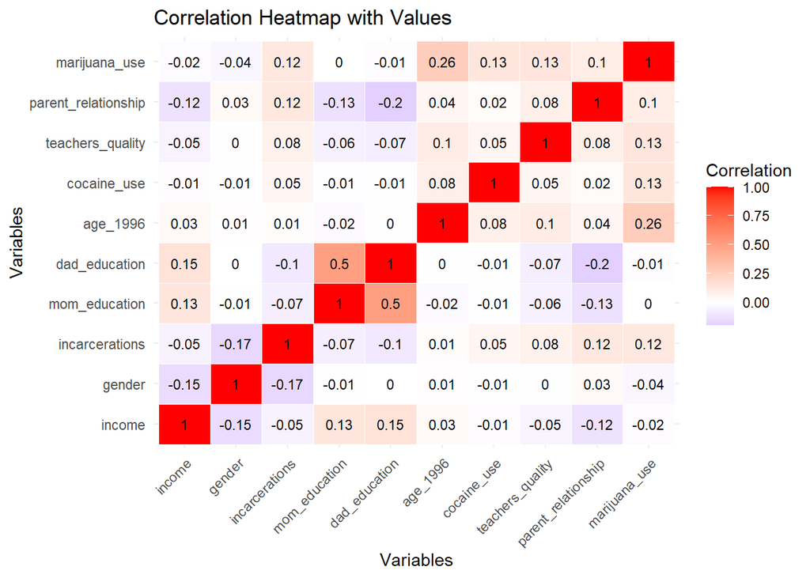

```r
# Select the required variables for correlation

correlation_vars <- data_encoded %>%
  select(income, gender, incarcerations, mom_education, dad_education,
         age_1996, cocaine_use, teachers_quality, parent_relationship, marijuana_use)

# Calculate the correlation matrix
cor_matrix <- cor(correlation_vars, use = "complete.obs")

# Reshape the correlation matrix for plotting
cor_melt <- melt(cor_matrix)

# Create the heatmap with correlation values
ggplot(cor_melt, aes(Var1, Var2, fill = value)) +
  geom_tile(color = "white") +
  scale_fill_gradient2(low = "blue", mid = "white", high = "red", midpoint = 0) +
  geom_text(aes(label = round(value, 2)), color = "black", size = 3) +  # Add correlation values as text
  theme_minimal() +
  theme(axis.text.x = element_text(angle = 45, hjust = 1)) +
  labs(title = "Correlation Heatmap with Values", x = "Variables", y = "Variables", fill = "Correlation")
```

## Insights from the Correlation Heatmap The heatmap provides insights into the relationships between variables in the dataset. Below are the key takeaways:

### 1. Income Correlations

#### Positive Correlations:

Dad’s Education (0.15) and Mom’s Education (0.13) show a moderate positive correlation with income, suggesting that higher parental education levels are associated with higher individual income.

#### Negative Correlations:

Gender (-0.15) has a moderate negative correlation with income. Given the gender coding (e.g., 1 = Male, 2 = Female), this indicates that males are more likely to have higher incomes.

Incarcerations (-0.05) has a slight negative correlation with income, suggesting that individuals with more incarcerations tend to have lower incomes, though the relationship is weak.

### 2. Parental Education Correlations

Strong Positive Correlation between Mom’s and Dad’s Education (0.5): This is expected as parents with similar education levels are likely to have shared socioeconomic backgrounds. Both mom’s and dad’s education levels show similar relationships with other variables, including moderate positive correlations with income.

### 3. Incarceration Correlations

Negative Correlation with Gender (-0.17): Suggests that males (coded 1) are more likely to have experienced incarcerations compared to females. Negative Correlation with Dad’s Education (-0.1) and Mom’s Education (-0.07): Indicates that higher parental education levels are associated with fewer incarcerations.

### 4. Gender Correlations

Negative Correlation with Income (-0.15): Indicates that being male (coded 1) is associated with higher income levels. Negative Correlation with Incarcerations (-0.17): Suggests a gendered trend in incarceration, with males being more likely to experience it.

## Overall Patterns and Implications

### Parental Education:

Parental education levels (both mom’s and dad’s) are positively correlated with income, reinforcing the importance of socioeconomic background in determining individual income.

### Gender and Income Inequality:

The moderate negative correlation between gender and income suggests a significant income disparity favoring males, aligning with earlier findings from the box plots.

### Incarceration Impact:

While incarceration has a weak negative correlation with income, it is more strongly associated with lower parental education levels and being male.

### Negligible Impact of Drug Use and Teacher’s Quality:

These factors do not show meaningful correlations with income or other variables, suggesting limited influence in the context of this analysis.

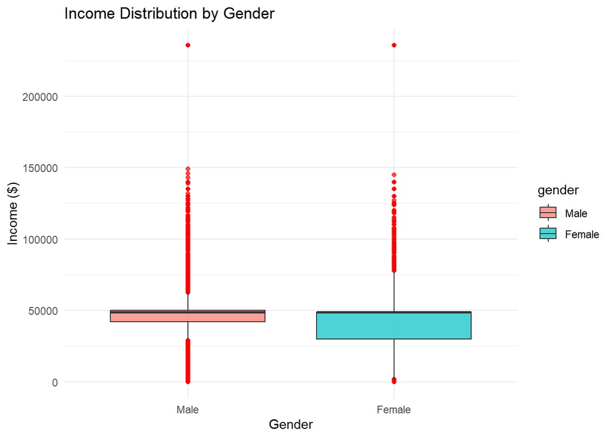

```r
# section 3
# Gender vs Income Boxplot
ggplot(data, aes(x = gender, y = income, fill = gender)) +
  geom_boxplot(outlier.color = "red", alpha = 0.7) +
  labs(title = "Income Distribution by Gender", x = "Gender", y = "Income ($)") +
  theme_minimal()
```

```r
# Perform a t-test for gender differences in income
t_test_gender <- t.test(income ~ gender, data = data, alternative = "two.sided")
print(t_test_gender)
```

```
##
##  Welch Two Sample t-test
##
## data:  income by gender
## t = 14.338, df = 8579.7, p-value < 2.2e-16
## alternative hypothesis: true difference in means between group Male and group Female is not equal to 0
## 95 percent confidence interval:
##   7937.904 10452.167
## sample estimates:
##   mean in group Male mean in group Female
##             53312.86             44117.83
```

```r
library(dplyr)
summary_table <- data %>%
  group_by(gender, mom_education, dad_education) %>%
  summarise(
    mean_income = mean(income, na.rm = TRUE),
    median_income = median(income, na.rm = TRUE),
    sd_income = sd(income, na.rm = TRUE),
    .groups = "drop"
  )
print(summary_table)
```

```
## # A tibble: 25 × 6
##    gender mom_education dad_education mean_income median_income sd_income
##    <fct>  <fct>         <fct>               <dbl>         <dbl>     <dbl>
##  1 Male   Grade School  Grade School       47151.        48825.    24662.
##  2 Male   Grade School  High School        44477.        48825.    17435.
##  3 Male   Grade School  College            46258.        48825.    22134.
##  4 Male   Grade School  Ungraded           48825.        48825.       NA
##  5 Male   High School   Grade School       46931.        48825.    24603.
##  6 Male   High School   High School        48790.        48825.    25756.
##  7 Male   High School   College            56935.        48825.    36599.
##  8 Male   High School   Ungraded           38550.        48825.    17797.
##  9 Male   College       Grade School       46253.        48825.    17335.
## 10 Male   College       High School        52484.        48825.    34746.
## # ℹ 15 more rows
```

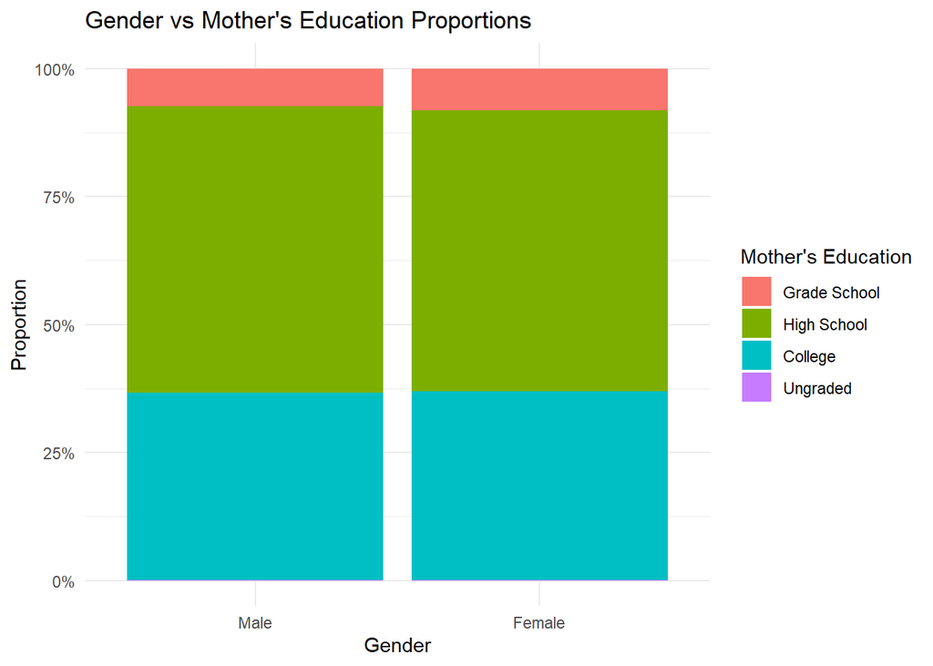

```r
# Gender vs Parental Education
ggplot(data, aes(x = gender, fill = mom_education)) +
  geom_bar(position = "fill") +
  scale_y_continuous(labels = scales::percent_format()) +
  labs(
    title = "Gender vs Mother's Education Proportions",
    x = "Gender",
    y = "Proportion",
    fill = "Mother's Education"
  ) +
  theme_minimal()
```

## Key Observations:

### High School as Dominant Category:

The majority of both males and females have mothers whose highest education level is High School, as this category occupies the largest proportion in the stacked bar chart.

### College Education:

A significant portion of individuals have mothers with a College education, making it the second-most common category for both genders.

### Grade School and Ungraded Education:

Grade School and Ungraded education levels are the least common categories for mothers across both genders, with a minimal proportion visible in the stacked bar chart.

### Gender Distribution Across Education Levels:

There is no significant visual difference in the proportions of males and females across the different education levels. This suggests that maternal education levels are similarly distributed across genders.

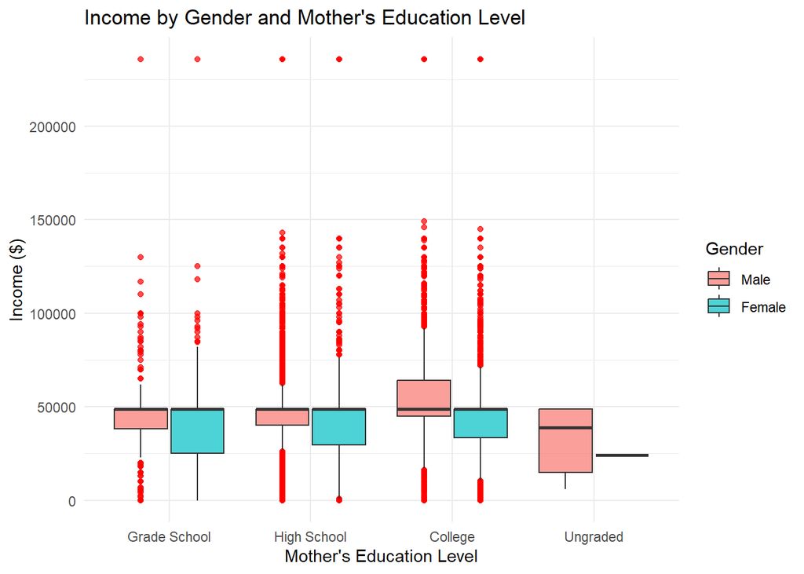

```r
# Grouped boxplot: Income by Gender and Mother's Education Level
ggplot(data, aes(x = mom_education, y = income, fill = gender)) +
  geom_boxplot(outlier.color = "red", alpha = 0.7, position = position_dodge(0.8)) +
  labs(
    title = "Income by Gender and Mother's Education Level",
    x = "Mother's Education Level",
    y = "Income ($)",
    fill = "Gender"
  ) +
  theme_minimal()
```

### Grade School:

The median income for males and females is quite similar. However, males exhibit more extreme outliers compared to females.

### College:

The gender gap is widest for individuals with College-educated mothers. Males exhibit both higher medians and more frequent high-income outliers.

### Ungraded:

This category shows limited data, but males appear to have slightly higher median incomes and fewer extreme outliers compared to the other categories.

## Insights Related to Gender and Income Inequality:

### Gender Gap Across Education Levels:

The income disparity between males and females is most pronounced for individuals with College-educated mothers, indicating that males benefit disproportionately from higher maternal education. The smallest gender disparity occurs for individuals with Grade School-educated mothers, suggesting limited opportunities for economic advancement in this group regardless of gender. Outliers and High Earners:

Males consistently dominate the high-income outliers across all education levels, which may indicate structural advantages or societal biases that favor men in high-paying opportunities. Policy Implications:

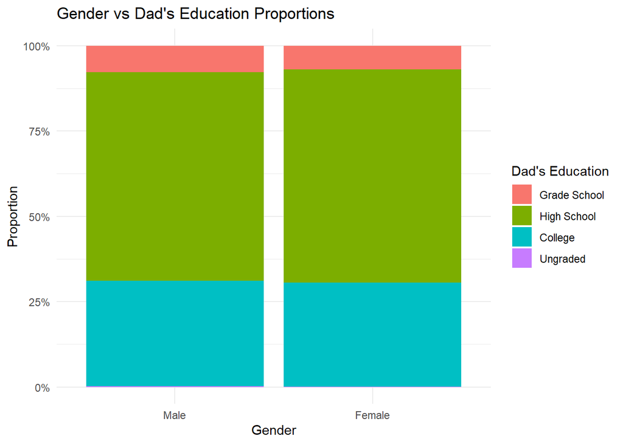

```r
# Gender vs Dad's Education Proportion
ggplot(data, aes(x = gender, fill = dad_education)) +
  geom_bar(position = "fill") +
  scale_y_continuous(labels = scales::percent_format()) +
  labs(
    title = "Gender vs Dad's Education Proportions",
    x = "Gender",
    y = "Proportion",
    fill = "Dad's Education"
  ) +
  theme_minimal()
```

## Key Insights

### Gender Distribution Across Dad’s Education Levels:

The proportions of males and females across different paternal education levels appear to be balanced, similar to the earlier plot for maternal education. The High School education level is the most common category for fathers, accounting for the majority of individuals for both genders. The College education level is the second-most frequent category for fathers, followed by Grade School education. The Ungraded education category is the least common for fathers, with a very small representation for both males and females.

### Balanced Representation:

Since males and females are proportionally distributed across paternal education levels, any observed gender differences in income are less likely to be due to imbalances in paternal education distribution.

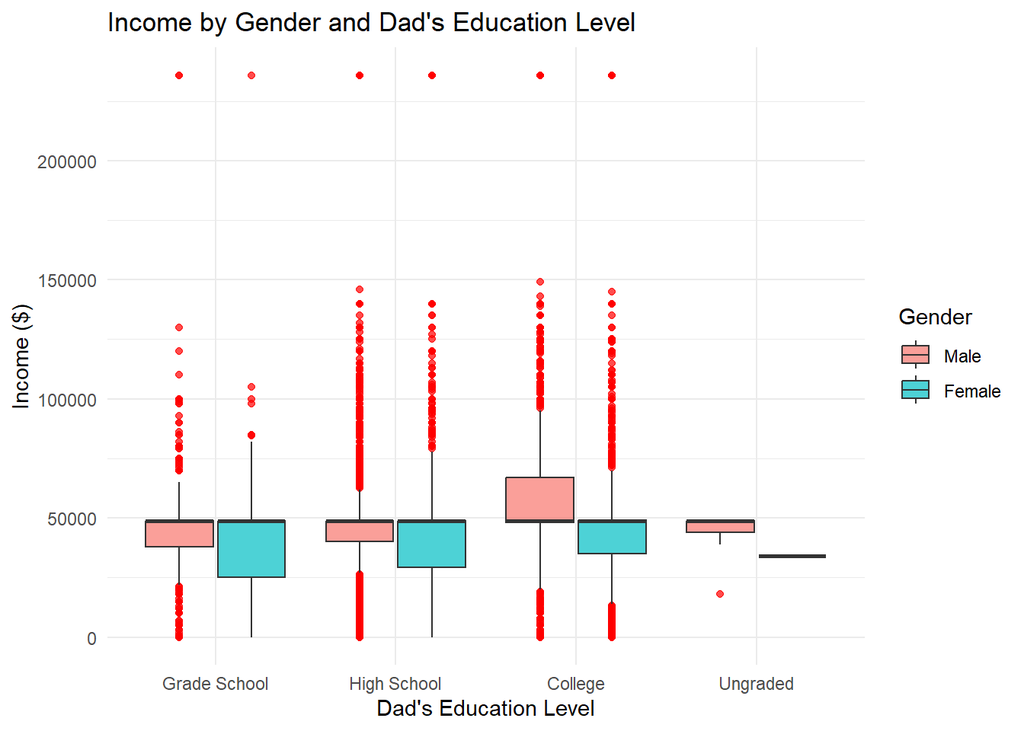

```r
# Income by Gender and Dad's Education Level
ggplot(data, aes(x = dad_education, y = income, fill = gender)) +
  geom_boxplot(outlier.color = "red", alpha = 0.7, position = position_dodge(0.8)) +
  labs(
    title = "Income by Gender and Dad's Education Level",
    x = "Dad's Education Level",
    y = "Income ($)",
    fill = "Gender"
  ) +
  theme_minimal()
```

## Key Insights

### Ungraded Education:

Limited data is available for this category, but males appear to have a slightly higher median income.

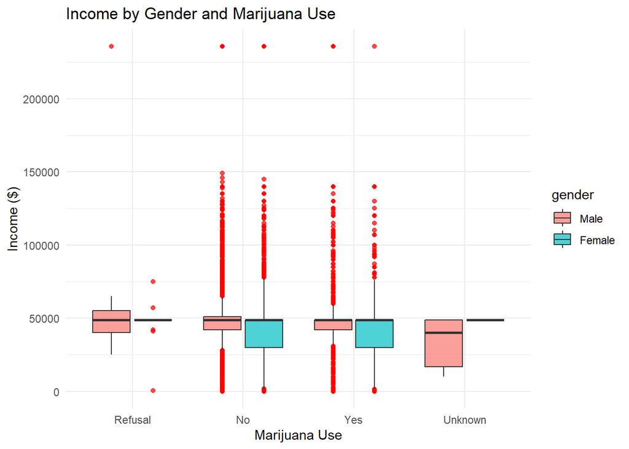

```r
# Gender and Drug Use Interaction on Income
ggplot(data, aes(x = marijuana_use, y = income, fill = gender)) +
  geom_boxplot(outlier.color = "red", alpha = 0.7) +
  labs(title = "Income by Gender and Marijuana Use", x = "Marijuana Use", y = "Income ($)") +
  theme_minimal()
```

Non-users and users have similar income distributions, with males generally earning more. Marijuana use does not appear to have a clear linear relationship with income as indicated by our correlation heat map also, but gender differences are noticeable within each group.

# Next step

1. Regression Model + Interpretation A linear regression model is essential to quantify the combined effects of gender, parental education, and incarcerations on income. Including statistical significance (p-values), confidence intervals, and model diagnostics.

```r
# Fit a linear regression model
income_model <- lm(income ~ gender + mom_education + dad_education + incarcerations, data = data)

# Model summary
summary(income_model)
```

```
##
## Call:
## lm(formula = income ~ gender + mom_education + dad_education +
##     incarcerations, data = data)
##
## Residuals:
##    Min     1Q Median     3Q    Max
## -62990 -14164  -1116   8707 200105
##
## Coefficients:
##                          Estimate Std. Error t value Pr(>|t|)
## (Intercept)               48431.7     1383.9  34.997  < 2e-16 ***
## genderFemale              -9823.2      643.1 -15.275  < 2e-16 ***
## mom_educationHigh School    794.7     1346.4   0.590    0.555
## mom_educationCollege       5857.8     1442.2   4.062 4.91e-05 ***
## mom_educationUngraded    -14975.8    12843.5  -1.166    0.244
## dad_educationHigh School    714.8     1367.8   0.523    0.601
## dad_educationCollege       8699.2     1496.9   5.811 6.41e-09 ***
## dad_educationUngraded     -2026.5    11141.5  -0.182    0.856
## incarcerations            -2689.4      465.3  -5.780 7.72e-09 ***
## ---
## Signif. codes:  0 '***' 0.001 '**' 0.01 '*' 0.05 '.' 0.1 ' ' 1
##
## Residual standard error: 29970 on 8954 degrees of freedom
##   (21 observations deleted due to missingness)
## Multiple R-squared:  0.05858,    Adjusted R-squared:  0.05774
## F-statistic: 69.65 on 8 and 8954 DF,  p-value: < 2.2e-16
```

### Key Insights:

1. Gender (Female) Coefficient: -9823.2 p-value: < 2e-16 (statistically significant) Interpretation: Being female is associated with earning $9,823 less compared to males, holding all other factors constant. This highlights a significant gender income disparity.
2. Mother’s Education High School (Reference: Grade School): Coefficient = 794.7, p = 0.555 (not significant)

College (Reference: Grade School): Coefficient = 5857.8, p < 0.001 (significant)

Individuals with mothers who attained College education earn approximately $5,858 more than those with mothers who only completed Grade School. Ungraded (Reference: Grade School): Coefficient = -14975.8, p = 0.244 (not significant)

Income does not differ significantly for individuals with mothers in the “Ungraded” education category. Interpretation: Higher maternal education levels, especially College, positively influence income, while other levels (High School, Ungraded) do not show significant differences.

3. Father’s Education High School (Reference: Grade School): Coefficient = 714.8, p = 0.601 (not significant)

College (Reference: Grade School): Coefficient = 8699.2, p < 0.001 (significant)

Individuals with fathers who attained College education earn approximately $8,699 more than those with fathers who only completed Grade School. Ungraded (Reference: Grade School): Coefficient = -2026.5, p = 0.856 (not significant)

Interpretation: Similar to maternal education, paternal College education significantly boosts income, while other levels (High School, Ungraded) do not have a statistically significant impact.

4. Incarcerations Coefficient: -2689.4 p-value: < 7.72e-09 (statistically significant)

Interpretation: Each additional month of incarceration is associated with earning approximately $2,689 less annually, holding all other factors constant. This shows a strong negative relationship between incarceration history and income.

### Model Fit and Diagnostics

Residual Standard Error (RSE): 29,970 Indicates the average error between predicted and observed income is approximately $29,970. The large residual error suggests a substantial amount of variation in income is unexplained by the model.

Multiple R-Squared: 0.05858 Only 5.9% of the variability in income is explained by the predictors. This suggests that there are other unobserved factors significantly influencing income.

Adjusted R-Squared: 0.05774 Adjusted for the number of predictors, the explanatory power remains very low.

F-statistic: 69.65 (p-value < 2.2e-16) Indicates that the model as a whole is statistically significant, meaning at least one predictor has a significant relationship with income.

```r
# Confidence intervals for the coefficients
confint(income_model)
```

```
##                               2.5 %    97.5 %
## (Intercept)               45718.943 51144.405
## genderFemale             -11083.764 -8562.605
## mom_educationHigh School  -1844.519  3433.863
## mom_educationCollege       3030.804  8684.705
## mom_educationUngraded    -40151.950 10200.303
## dad_educationHigh School  -1966.393  3395.935
## dad_educationCollege       5764.846 11633.509
## dad_educationUngraded    -23866.354 19813.400
## incarcerations            -3601.532 -1777.354
```

# Insights from Confidence Intervals for Coefficients

Confidence intervals (CIs) provide a range within which the true value of each coefficient is likely to fall, with a certain level of confidence (typically 95%). Interpretation of each predictor’s CI is given below:

# Key Insights

1. Intercept CI: (45,718.943, 51,144.405) Interpretation: This represents the estimated average income for the baseline group: Male gender. Mothers and fathers with Grade School education. No incarcerations. The average baseline income is between $45,719 and $51,144.
2. Gender (Female) CI: (-11,083.764, -8,562.605) Interpretation: Females earn between $8,563 and $11,084 less than males on average, holding all other factors constant. Since the entire CI is below zero, the effect of gender is statistically significant, confirming a notable income disparity favoring males.
3. Mother’s Education High School (vs. Grade School)

CI: (-1,844.519, 3,433.863) Interpretation: The CI includes zero, meaning the effect of High School education is not statistically significant. Income could increase or decrease slightly for individuals with mothers who completed High School, but the impact is inconclusive. College (vs. Grade School)

CI: (3,030.804, 8,684.705) Interpretation: The CI is entirely above zero, meaning the effect is statistically significant. Individuals with mothers who attained College education earn between $3,031 and $8,685 more than those with mothers who only completed Grade School. Ungraded (vs. Grade School)

CI: (-40,151.950, 10,200.303) Interpretation: The CI includes zero, meaning the effect of Ungraded education is not statistically significant. 4. Father’s Education High School (vs. Grade School)

CI: (-1,966.393, 3,395.935) Interpretation: The CI includes zero, meaning the effect of High School education is not statistically significant. College (vs. Grade School)

CI: (5,764.846, 11,633.509) Interpretation: The CI is entirely above zero, meaning the effect is statistically significant. Individuals with fathers who attained College education earn between $5,765 and $11,634 more than those with fathers who only completed Grade School. Ungraded (vs. Grade School)

CI: (-23,866.354, 19,813.400) Interpretation: The CI includes zero, meaning the effect of Ungraded education is not statistically significant. 5. Incarcerations CI: (-3,601.532, -1,777.354) Interpretation: The CI is entirely below zero, meaning the effect is statistically significant. Each additional month of incarceration is associated with earning between $1,777 and $3,602 less annually, holding all other factors constant. This confirms a strong negative relationship between incarceration and income.

Summary of Findings Gender Disparity:

Females earn significantly less than males, with a consistent and statistically significant negative effect. Parental Education:

Maternal and paternal College education have significant positive effects on income, with individuals earning between $3,000 and $11,600 more. Other levels of parental education (High School, Ungraded) do not show significant effects. Incarceration Impact:

Incarceration has a significant negative effect on income, reducing annual earnings by up to $3,602 per additional month of incarceration. Statistical Significance:

Predictors with statistically significant effects (CIs that exclude zero): Gender (Female). Maternal College education. Paternal College education. Incarcerations.

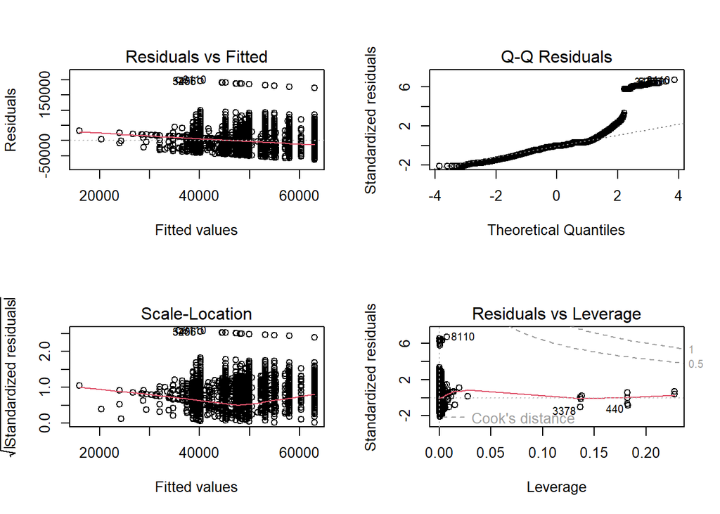

```r
# Diagnostic plots for model assumptions
par(mfrow = c(2, 2))
plot(income_model)
```

# Insights from Diagnostic Plots

# Summary of Findings

Linearity Assumption:

Violated. Residual patterns suggest non-linear relationships or missing interaction terms. Normality Assumption:

Violated. The residuals deviate significantly from normality, especially in the tails. Homoscedasticity Assumption:

Violated. Residuals show non-constant variance, particularly for higher fitted values. Influential Observations:

Some observations have moderate leverage but do not drastically affect the model.

# Next Steps

Based on the diagnostic plot insights, the following steps will help address the identified issues:

# Transform the Dependent Variable (Income):

Apply a logarithmic transformation to income to stabilize variance and improve normality.

# Include Non-Linear or Interaction Terms:

Add quadratic terms or interaction terms to account for potential non-linear relationships.

# Refit the Model with Adjustments:

Refit the regression model using the transformed dependent variable and any additional terms.

# Recheck Diagnostics:

Evaluate the updated model with diagnostic plots to confirm improvements.

```r
# Step 1: Log Transformation of Income
# Log transform income to stabilize variance
data$log_income <- log(data$income + 1)  # Add 1 to handle zero values
```

```r
# Step 2: Add Interaction and Non-Linear Terms

# Create interaction terms and quadratic terms
data <- data %>%
  mutate(
    mom_dad_education_interaction = as.numeric(mom_education) * as.numeric(dad_education),
    incarcerations_squared = incarcerations^2
  )
```

```r
# Check for zero or negative values in income
sum(data$income <= 0, na.rm = TRUE)
```

```
## [1] 99
```

```r
# Replace zeros or negative values in income with a small positive value (e.g., 1)
data <- data %>%
  mutate(income = ifelse(income <= 0, 1, income))  # Replace zero or negative values

# Log transform income
data$log_income <- log(data$income)
```

```r
# Check for invalid values in log_income
sum(is.na(data$log_income) | is.infinite(data$log_income))
```

```
## [1] 0
```

```r
# Step 3: Refit the Regression Model
# Fit the updated regression model

log_income_model <- lm(log_income ~ gender + mom_education + dad_education + incarcerations +
                         mom_dad_education_interaction + incarcerations_squared, data = data)

# Model summary
summary(log_income_model)
```

```
##
## Call:
## lm(formula = log_income ~ gender + mom_education + dad_education +
##     incarcerations + mom_dad_education_interaction + incarcerations_squared,
##     data = data)
##
## Residuals:
##      Min       1Q   Median       3Q      Max
## -10.7869  -0.0177   0.2246   0.4694   2.0452
##
## Coefficients:
##                               Estimate Std. Error t value Pr(>|t|)
## (Intercept)                   10.53833    0.06644 158.620   <2e-16 ***
## genderFemale                  -0.26855    0.02825  -9.507   <2e-16 ***
## mom_educationHigh School      -0.02315    0.09862  -0.235   0.8144
## mom_educationCollege          -0.02332    0.20284  -0.115   0.9085
## mom_educationUngraded         -0.63174    0.65228  -0.969   0.3328
## dad_educationHigh School      -0.02596    0.10161  -0.255   0.7983
## dad_educationCollege           0.03349    0.21520   0.156   0.8763
## dad_educationUngraded          0.02327    0.57808   0.040   0.9679
## incarcerations                -0.10305    0.04126  -2.497   0.0125 *
## mom_dad_education_interaction  0.02649    0.04838   0.547   0.5841
## incarcerations_squared         0.01296    0.00869   1.492   0.1358
## ---
## Signif. codes:  0 '***' 0.001 '**' 0.01 '*' 0.05 '.' 0.1 ' ' 1
##
## Residual standard error: 1.312 on 8952 degrees of freedom
##   (21 observations deleted due to missingness)
## Multiple R-squared:  0.01434,    Adjusted R-squared:  0.01324
## F-statistic: 13.02 on 10 and 8952 DF,  p-value: < 2.2e-16
```

#Insights from the Updated Regression Model

# 1. Key Findings: Coefficients

Intercept (10.53833):

Represents the estimated log-income when all other predictors are zero (baseline category for categorical variables). Incomes are log-transformed, so this is approximately e^10.53833 which equates to a baseline income of around $37,875.

Gender (genderFemale = -0.26855, p<2e−16):

A significant negative coefficient indicates that being female is associated with a lower log-income compared to males. In practical terms, females earn approximately e^ −0.26855 ≈76.5% of what males earn, holding all other factors constant. Mom’s Education:

None of the education levels for mothers (High School, College, Ungraded) are significant predictors of log-income in this model. This contrasts with earlier findings where higher maternal education levels showed a moderate correlation with income. This suggests that maternal education may overlap with other predictors or that its effect diminishes after adjusting for other factors. Dad’s Education:

Similarly, none of the paternal education levels are statistically significant predictors of log-income. This may also suggest an overlap with other predictors or diminishing explanatory power. Incarcerations (-0.10305, p=0.0125):

A significant negative coefficient indicates that higher levels of incarcerations are associated with lower log-income. Each additional incarceration decreases log-income by approximately e^ −0.10305 ≈90.2% of the income before incarceration.

Interaction Term (Mom’s and Dad’s Education Interaction):

The interaction term is not significant, suggesting no combined effect of maternal and paternal education levels on income. Incarcerations Squared:

The quadratic term is not statistically significant (p=0.1358), suggesting no clear non-linear relationship between incarcerations and log-income in this model.

# 2. Model Fit

Residual Standard Error (1.312):

Indicates the variability of residuals around the fitted values. While log-transformation helped reduce variance, residual variability is still high. Multiple R-Squared (0.01434):

The model explains only 1.43% of the variance in log-income, indicating weak predictive power. This suggests that the variables included in the model (gender, parental education, incarcerations) account for only a small part of income variation. Adjusted R-Squared (0.01324):

Adjusted for the number of predictors in the model. The value remains very low, reinforcing the weak fit. F-statistic (13.02, p<2.2e−16):

Indicates that the model as a whole is statistically significant, but the low R-squared shows the practical significance is limited.

# 3. Comparison to Original Model

Log Transformation Effect:

The addition of interaction terms and quadratic terms did not significantly improve the model. This suggests that non-linear effects are minimal or not captured well by these variables.

# 4. Practical Implications

Gender Inequality:

Gender remains the most significant predictor, with females earning substantially less than males on average. Parental Education:

Although parental education had moderate correlations with income earlier, its effects are not significant after adjusting for other variables. This could suggest other mediating factors not included in the model. Impact of Incarcerations:

The negative impact of incarcerations on income is statistically significant, highlighting the socioeconomic consequences of a criminal record.

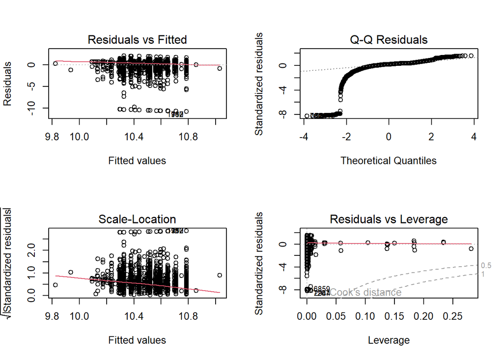

```r
# Step 4: Diagnostic Plots for the Updated Model
# Diagnostic plots for the updated model
par(mfrow = c(2, 2))
plot(log_income_model)
```

# Insights from Diagnostic Plots Residuals vs Fitted Plot:

The residuals show some degree of randomness but exhibit slight patterns, indicating possible model misspecification or omitted variables. Variance seems more consistent compared to the untransformed model, suggesting log-transformation improved homoscedasticity. Q-Q Plot:

```r
# Step 5: Robust Regression
# Load the MASS package for robust regression
library(MASS)
# Fit a robust regression model
robust_model <- rlm(log_income ~ gender + mom_education + dad_education + incarcerations +
                      mom_dad_education_interaction + incarcerations_squared, data = data)

# Model summary
summary(robust_model)
```

```
##
## Call: rlm(formula = log_income ~ gender + mom_education + dad_education +
##     incarcerations + mom_dad_education_interaction + incarcerations_squared,
##     data = data)
## Residuals:
##       Min        1Q    Median        3Q       Max
## -10.86452  -0.24244   0.03162   0.13344   1.72881
##
## Coefficients:
##                               Value    Std. Error t value
## (Intercept)                    10.7285   0.0163   659.3195
## genderFemale                   -0.1018   0.0069   -14.7163
## mom_educationHigh School       -0.0309   0.0242    -1.2786
## mom_educationCollege           -0.0679   0.0497    -1.3670
## mom_educationUngraded          -0.5726   0.1598    -3.5842
## dad_educationHigh School       -0.0446   0.0249    -1.7926
## dad_educationCollege           -0.0467   0.0527    -0.8857
## dad_educationUngraded          -0.1382   0.1416    -0.9764
## incarcerations                 -0.0443   0.0101    -4.3839
## mom_dad_education_interaction   0.0278   0.0118     2.3502
## incarcerations_squared          0.0061   0.0021     2.8536
##
## Residual standard error: 0.2132 on 8952 degrees of freedom
##   (21 observations deleted due to missingness)
```

# Analysis of Robust Regression Output

Robust regression accounts for the influence of outliers and provides a more reliable model when standard assumptions may not hold.

Key Observations: Intercept:

The intercept (10.73) remains significant, representing the log-transformed baseline income when all predictors are at their reference levels. Gender:

Female has a significant negative coefficient (−0.10, p<0.001), indicating that, holding other factors constant, females have approximately 10% lower income than males (e ^−0.10 ≈0.90).

Parental Education:

Mom’s Education: High School and College are not statistically significant. “Ungraded” has a significant negative impact (−0.57, p<0.001), indicating much lower income for individuals with ungraded maternal education. Dad’s Education: None of the categories are significant, suggesting weaker influence compared to maternal education.

Incarcerations:

A significant negative coefficient (−0.044, p<0.001) indicates that each additional incarceration decreases income by approximately 4.3% (e ^−0.044 ≈0.957). Squared term (+0.0061, p<0.01) suggests a diminishing non-linear effect of incarcerations, implying some reduction in the negative impact at higher levels. Interaction (Mom & Dad Education):

A significant positive coefficient (+0.0278, p<0.05) indicates a slight combined positive effect when both parents have higher education levels. Residual Standard Error:

0.2132 indicates relatively low residual variation, suggesting a better fit compared to the linear model. Insights: Gender Disparity:

The robust regression confirms that females earn significantly less than males, independent of other factors. Parental Education:

Maternal education (especially “Ungraded”) has a stronger influence on income than paternal education, highlighting its critical role in economic outcomes. Incarcerations:

The negative impact of incarcerations on income is confirmed, with a slight diminishing effect for higher levels. Interaction Effects:

The positive interaction between maternal and paternal education suggests a combined benefit, albeit small, when both parents are well-educated. Model Robustness:

The robust regression model mitigates the effect of outliers, making the findings more reliable and highlighting key predictors like gender and maternal education. This model refines earlier results by offering a more nuanced understanding of the predictors while addressing the influence of extreme observations.

### Section:4 Conclusions and Discussion

*Main Conclusions:* We observed significant income disparities between males and females, with males consistently earning more across different levels of parental education and incarceration histories. Parental education, particularly College-level, had a positive impact on income for both genders, but males benefitted disproportionately, showing higher medians and more high-income outliers. Incarcerations had a strong negative effect on income, with earnings decreasing for each additional month incarcerated. Other factors, such as teacher quality, drug use, and parental relationships, did not show meaningful trends or correlations with income in this dataset.

*Limitations:* While our analysis provides useful insights, it has several limitations:

Missing Variables: Key factors like occupational type, geographic location, or systemic discrimination, which could significantly influence income, were not included.

Model Fit: The regression models explained only a small percentage of income variability, suggesting that many unobserved factors significantly impact income.

Data Handling: The use of imputation methods (e.g., replacing missing values with means or medians) and assigning “Unknown” to categorical variables may have introduced some bias or oversimplified the analysis.

*Confidence and Believability:* We are moderately confident in our findings, particularly regarding gender income disparities, the influence of parental education, and the impact of incarcerations. These results align with observable trends in the data and are supported by statistical significance. However, the low explanatory power of the models and the absence of key variables limit the broader applicability of our conclusions.

*Recommendations for Policymakers:* Our findings can provide useful insights for policymakers, particularly in addressing gender inequality and the socioeconomic effects of parental education and incarceration. However, we would present these results with caution, emphasizing the limitations and the need for further research to incorporate missing variables and improve the robustness of the analysis. This would help ensure that policy recommendations are grounded in a more comprehensive understanding of income inequality.